# Reproducible Research: Peer Assessment 1

LuFo

August 10, 2015

# 1 Loading and preprocessing the data

File https://d396qusza40orc.cloudfront.net/repdata%2Fdata%2Factivity.zip to be downloaded to local drive, unzipped and read.

```r
download.file("https://d396qusza40orc.cloudfront.net/repdata/data/activity.zip",
              "./activity.zip",
              "wget",
              quiet = TRUE,
              mode = "w",
              cacheOK = TRUE,
              extra = getOption("download.file.extra"))
df <- read.csv(unz("activity.zip", "activity.csv"))
```

Check data:

```r
str(df)
```

```
## 'data.frame':    17568 obs. of  3 variables:
##  $ steps   : int  NA NA NA NA NA NA NA NA NA NA ...
##  $ date    : Factor w/ 61 levels "2012-10-01","2012-10-02",..: 1 1 1 1 1 1 1 1 1 1 ...
##  $ interval: int  0 5 10 15 20 25 30 35 40 45 ...
```

- column data is a factor and not as.Date()

```r
sum(complete.cases(df))
```

```
## [1] 15264
```

- there are 2304 incomplete observations (17568 rows - 15264 complete)

Keeping this in mind it seems to be ok for further processing.

# 2 What is mean total number of steps taken per day?

While there are several ways of subsetting or sub summation I decide for convenient dplyr package.

```r
library(dplyr)
```

## 2.1 Calculate the total number of steps taken per day

```r
stepsperday <-  df %>%
                na.omit() %>%
                group_by(date) %>%
                summarise(totalSteps=sum(steps))
```

A list of steps per day has been calculated, see head():

```r
head(stepsperday)
```

```
## Source: local data frame [6 x 2]
##
##         date totalSteps
## 1 2012-10-02        126
## 2 2012-10-03      11352
## 3 2012-10-04      12116
## 4 2012-10-05      13294
## 5 2012-10-06      15420
## 6 2012-10-07      11015
```

## 2.2 Make a histogram of the total number of steps taken each day

```r
library(ggplot2)
```

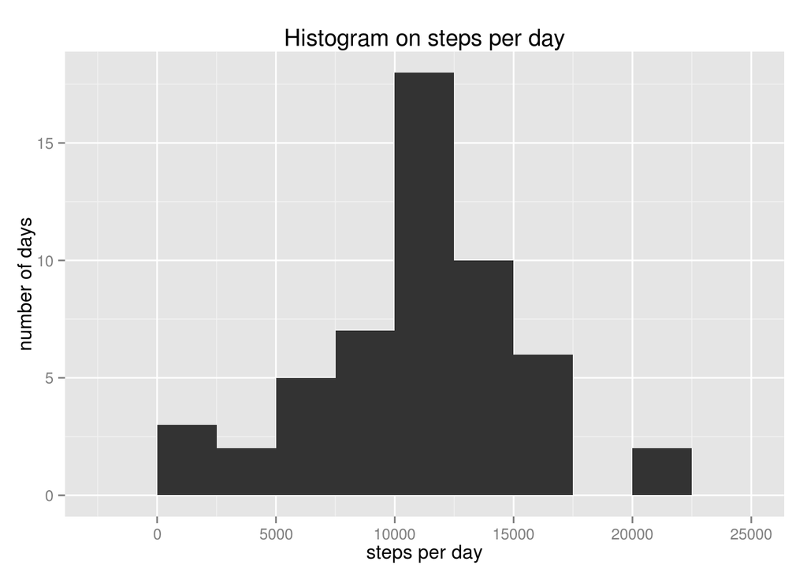

```r
qplot(totalSteps,
      data=stepsperday,
      geom="histogram",
      binwidth=2500,
      main="Histogram on steps per day",
      ylab="number of days",
      xlab="steps per day"
     )
```

## 2.3 Calculate and report the mean and median of the total number of steps taken per day

With stepsperday from 2.1 mean and median can be calculated.

```r
mean(stepsperday$totalSteps, na.rm=TRUE)
```

```
## [1] 10766.19
```

```r
median(stepsperday$totalSteps, na.rm=TRUE)
```

```
## [1] 10765
```

# 3 What is the average daily activity pattern?

## 3.1 Make a time series plot (i.e. type = “l”) of the 5-minute interval (x-axis) and the average number of steps taken, averaged across all days (y-axis)

```r
stepsoverday <- df %>%
                na.omit() %>%
                group_by(interval) %>%
                summarise(averagesteps=mean(steps))
```

List of steps over day is calculated, see head():

```r
head(stepsoverday)
```

```
## Source: local data frame [6 x 2]
##
##   interval averagesteps
## 1        0    1.7169811
## 2        5    0.3396226
## 3       10    0.1320755
## 4       15    0.1509434
## 5       20    0.0754717
## 6       25    2.0943396
```

```r
library(ggplot2)
```

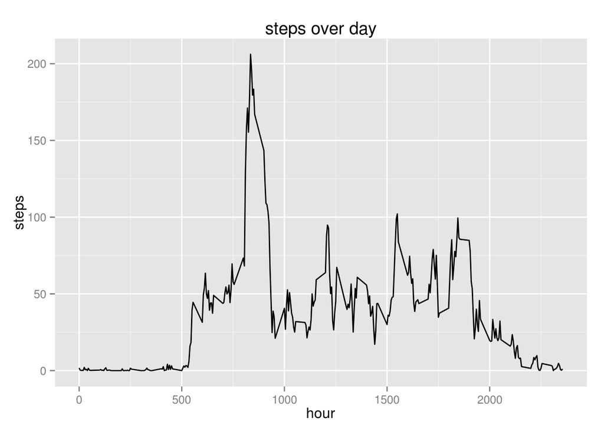

```r
qplot(x=interval,
      y=averagesteps,
      data=stepsoverday,
      geom="line",
      main="steps over day",
      ylab="steps",
      xlab="hour"
     )
```

## 3.2 Which 5-minute interval, on average across all the days in the dataset, contains the maximum number of steps?

With stepsoverday calculated in 3.1 its maximun can be calculated.

```r
which.max(stepsoverday$averagesteps)
```

```
## [1] 104
```

ok, 104th intervall is highest. [Raw estimation: With 12 intervals per hour this will be between 8:00am and 9:00am.]. To be precise:

```r
stepsoverday[which.max(stepsoverday$averagesteps), ]
```

```
## Source: local data frame [1 x 2]
##
##   interval averagesteps
## 1      835     206.1698
```

Interval ID 835 can be interpreted as time range 8:35am-8:40am with 206 steps per day in average. (Seems as going to work or school happens mostly at the same time while returns are distributed during whole day time until 7:00pm.)

# 4 Inputing missing values

## 4.1 Calculate and report the total number of missing values in the dataset (i.e. the total number of rows with NAs)

```r
sum(!complete.cases(df$steps))
```

```
## [1] 2304
```

```r
sum(!complete.cases(df$date))
```

```
## [1] 0
```

```r
sum(!complete.cases(df$interval))
```

```
## [1] 0
```

Ok, missing values are in steps only.

## 4.2 Devise a strategy for filling in all of the missing values in the dataset.

As calculated in 3, the mean for that 5-minute interval could be used to replace missing values.

## 4.3 Create a new dataset that is equal to the original dataset but with the missing data filled in

4.3.1 Set up a data frame that contains mean replacements for NA values. As used in 2 the dplyr functionality is convenient here, too.

```r
deltadf <-  df[which(is.na(df$steps)), ] %>%
            inner_join(stepsoverday, by="interval") %>%
            mutate(steps=averagesteps) %>%
            select(-averagesteps)
dim(deltadf)
```

```
## [1] 2304    3
```

4.3.2 Merge df (original data frame with NAs) together with deltadf (delta data frame with replacements) to a new updated data frame. For that origin data isn’t overwritten copy it to new data frame.

```r
updateddf <- df
updateddf[which(is.na(updateddf$steps)), 1] <- deltadf[ , 1]
str(updateddf)
```

```
## 'data.frame':    17568 obs. of  3 variables:
##  $ steps   : num  1.717 0.3396 0.1321 0.1509 0.0755 ...
##  $ date    : Factor w/ 61 levels "2012-10-01","2012-10-02",..: 1 1 1 1 1 1 1 1 1 1 ...
##  $ interval: int  0 5 10 15 20 25 30 35 40 45 ...
```

```r
sum(!complete.cases(updateddf$steps))
```

```
## [1] 0
```

```r
updatedstepsperday <- updateddf %>%
                      group_by(date) %>%
                      summarise(totalSteps=sum(steps))
```

Now the histogram

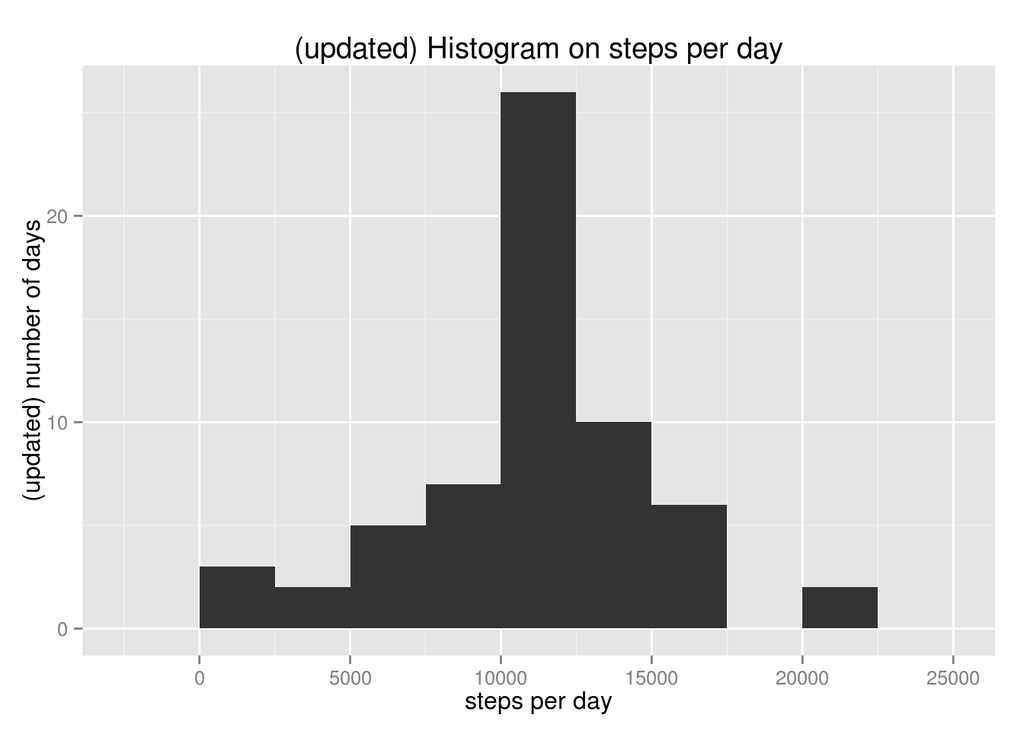

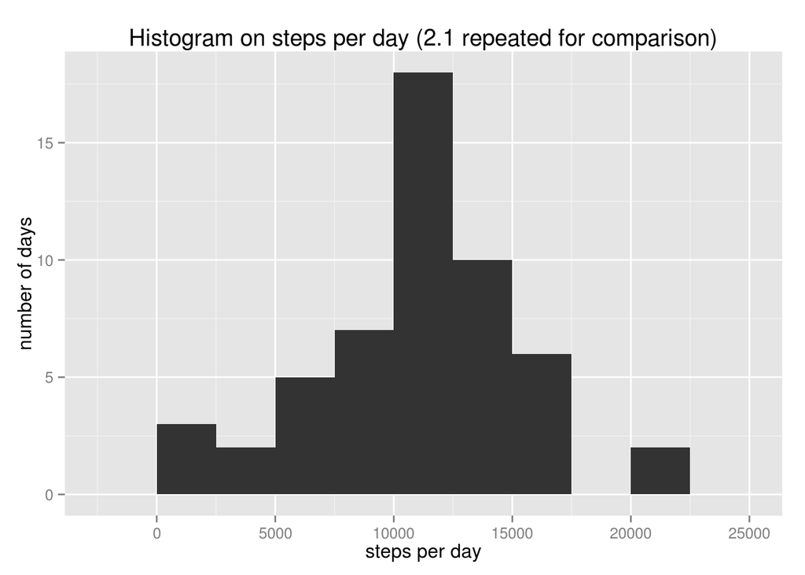

Histograms 2.1 and 4.4 differ visually, updated data is more centered to mean and has higher peak. To calculate the difference similar to 2.3.

```r
abs(median(stepsperday$totalSteps, na.rm=TRUE) - mean(stepsperday$totalSteps, na.rm=TRUE))
```

```
## [1] 1.188679
```

```r
abs(median(updatedstepsperday$totalSteps) - mean(updatedstepsperday$totalSteps))
```

```
## [1] 0
```

This shows that adding mssing values with mean equivalences shifts median to mean in updated data.

# 5 Are there differences in activity patterns between weekdays and weekends?

For this part the weekdays() function may be of some help here. Use the dataset with the filled-in missing values for this part.

## 5.1 Create a new factor variable in the dataset with two levels – “weekday” and “weekend” indicating whether a given date is a weekday or weekend day.

For not changing origin data following analysis is done on updated data frame. It is to change the date string into a date type, to evaluate each weekdayand to add new column to data.

1. Remark: Column date is of string in format YYYY-mm-dd and can be switched into date type by: as.Date(datafile[,“Date”], “%Y-%m-%d”).]
2. Remark: Well, yes, I’m currently located in Germany. After a short irritation of expected code not working I remembered Ubuntu’s System Settings | Language Support | Regional Formats being set to ‘Deutsch (Deutschland)’.

```r
updateddf <- updateddf %>%
               mutate(weekdays=ifelse(weekdays(as.Date(date, "%Y-%m-%d")) == "Samstag" |
                                      weekdays(as.Date(date, "%Y-%m-%d")) == "Sonntag",
                                      "weekend",
                                      "weekday"))
updateddf$weekdays <- as.factor(updateddf$weekdays)
```

no, that’s bad, I don’t want code to be dependent on localisation… let’s go for international as.POSIXlt(df$date)$wday returning numeric weekday (0-6 starting on Sunday).

```r
updateddf <- updateddf %>%
               mutate(wday=ifelse((as.POSIXlt(date, "%Y-%m-%d")$wday) == 0 |
                                  (as.POSIXlt(date, "%Y-%m-%d")$wday) == 6  ,
                                  "weekend",
                                  "weekday"))
updateddf$wday <- as.factor(updateddf$wday)
str(updateddf)
```

```
## 'data.frame':    17568 obs. of  5 variables:
##  $ steps   : num  1.717 0.3396 0.1321 0.1509 0.0755 ...
##  $ date    : Factor w/ 61 levels "2012-10-01","2012-10-02",..: 1 1 1 1 1 1 1 1 1 1 ...
##  $ interval: int  0 5 10 15 20 25 30 35 40 45 ...
##  $ weekdays: Factor w/ 2 levels "weekday","weekend": 1 1 1 1 1 1 1 1 1 1 ...
##  $ wday    : Factor w/ 2 levels "weekday","weekend": 1 1 1 1 1 1 1 1 1 1 ...
```

## 5.2 Make a panel plot containing a time series plot (i.e. type = “l”) of the 5-minute interval (x-axis) and the average number of steps taken, averaged across all weekday days or weekend days (y-axis).

```r
updatedstepsoverday <- updateddf %>%
                      group_by(interval, wday) %>%
                      summarise(averagesteps=mean(steps))
```

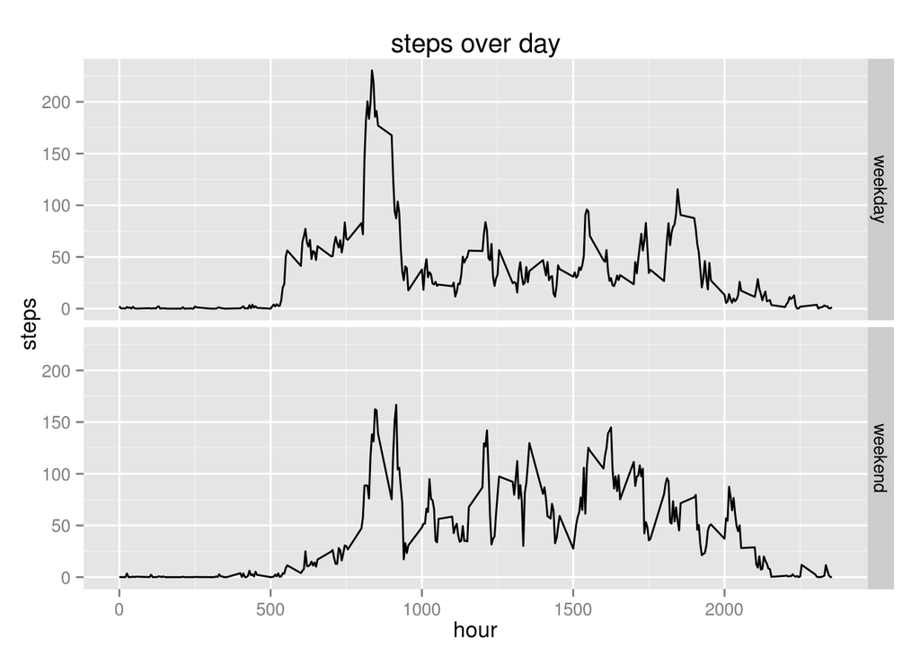

```r
qplot(x=interval,
      y=averagesteps,
      data=updatedstepsoverday,
      geom="line",
      main="steps over day",
      xlab="hour",
      ylab="steps",
      facets=wday ~ .)
```